# Estimation of the latitude & the longitude (ANOVA)

## Graphes de diagnostiques

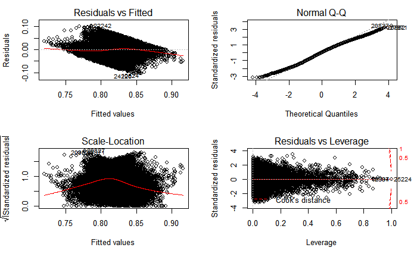

```r
#print('Latitude:')
par(mfrow=c(2,2))
plot(latitude.lm)

#print('Longitude:')
par(mfrow=c(2,2))
```

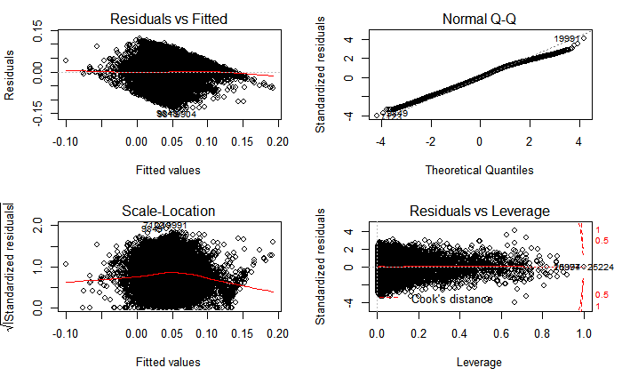

```r
plot(longitude.lm)
```

Il est à noter que l’ajout d’interactions à grandement améliorer les hypothèses des ML gaussiens aussi bien pour la latitude que la longitude.

## Selection des variables: anova1/bonferonni

Il devient impensable avec nos modèles à environ 2000 covariables de faire de la sélection de variables via AIC ou BIC (même avec des procédure de type backward ou forward).

```r
#Latitude
latanova<-anova(latitude.lm)
latanova
```

```
Analysis of Variance Table

Response: latitude
                    Df Sum Sq Mean Sq   F value    Pr(>F)
a                    1  1.392 1.39236 1276.7958 < 2.2e-16 ***
z                    1  0.219 0.21931  201.1079 < 2.2e-16 ***
e                    1  0.365 0.36472  334.4512 < 2.2e-16 ***
r                    1  0.045 0.04496   41.2259 1.376e-10 ***
t                    1  0.003 0.00313    2.8658 0.0904887 .
y                    1  0.784 0.78448  719.3638 < 2.2e-16 ***
u                    1  0.064 0.06418   58.8487 1.753e-14 ***
i                    1  0.377 0.37749  346.1596 < 2.2e-16 ***
o                    1  0.034 0.03373   30.9297 2.698e-08 ***
p                    1  0.038 0.03807   34.9125 3.485e-09 ***
q                    1  0.003 0.00297    2.7275 0.0986464 .
s                    1  0.149 0.14913  136.7477 < 2.2e-16 ***
d                    1  0.428 0.42779  392.2842 < 2.2e-16 ***
f                    1  0.040 0.03968   36.3861 1.637e-09 ***
g                    1  0.018 0.01834   16.8202 4.120e-05 ***
h                    1  0.205 0.20475  187.7586 < 2.2e-16 ***
j                    1  0.147 0.14745  135.2112 < 2.2e-16 ***
k                    1  0.093 0.09262   84.9302 < 2.2e-16 ***
l                    1  0.412 0.41227  378.0554 < 2.2e-16 ***
m                    1  0.281 0.28142  258.0662 < 2.2e-16 ***
w                    1  0.031 0.03097   28.3955 9.959e-08 ***
x                    1  0.000 0.00011    0.0991 0.7529496
c                    1  0.001 0.00085    0.7776 0.3778894
b                    1  0.010 0.01002    9.1895 0.0024360 **
n                    1  0.219 0.21905  200.8641 < 2.2e-16 ***
é                    1  0.020 0.02047   18.7737 1.476e-05 ***
tiret                1  0.000 0.00005    0.0431 0.8354569
è                    1  0.213 0.21270  195.0443 < 2.2e-16 ***
underscore           1  0.094 0.09407   86.2606 < 2.2e-16 ***
ç                    1  0.003 0.00338    3.1027 0.0781718 .
à                    1  0.000 0.00001    0.0059 0.9388514
ê                    1  0.002 0.00235    2.1525 0.1423437
ô                    1  0.004 0.00425    3.9016 0.0482481 *
ë                    1  0.016 0.01611   14.7690 0.0001218 ***
ÿ                    1  0.003 0.00299    2.7393 0.0979195 .
î                    1  0.005 0.00459    4.2065 0.0402781 *
```

[output cut: 117 more lines]

```
z:tiret              1  0.003 0.00340    3.1137 0.0776443 .
z:è                  1  0.002 0.00235    2.1563 0.1420005
z:underscore         1  0.000 0.00004    0.0407 0.8400848
z:ç                  1  0.001 0.00052    0.4748 0.4907800
z:à                  1  0.000 0.00044    0.4049 0.5245829
z:ê                  1  0.000 0.00005    0.0418 0.8380698
z:ô                  1  0.001 0.00100    0.9139 0.3390995
z:ë                  1  0.000 0.00014    0.1242 0.7245147
z:î                  1  0.001 0.00095    0.8696 0.3510635
z:â                  1  0.001 0.00141    1.2907 0.2559216
z:û                  1  0.000 0.00027    0.2501 0.6170230
z:A                  1  0.000 0.00029    0.2675 0.6050145
 [ getOption("max.print") est atteint -- 1673 lignes omises ]
---
Signif. codes:  0 ‘***’ 0.001 ‘**’ 0.01 ‘*’ 0.05 ‘.’ 0.1 ‘ ’ 1
```

```r
#Longitude
longanova<-anova(longitude.lm)
longanova
```

```
Analysis of Variance Table

Response: longitude
                    Df Sum Sq Mean Sq  F value    Pr(>F)
a                    1  0.486 0.48590 283.6768 < 2.2e-16 ***
z                    1  0.000 0.00016   0.0953 0.7574962
e                    1  0.070 0.07011  40.9316 1.599e-10 ***
r                    1  0.001 0.00055   0.3211 0.5709334
t                    1  0.026 0.02627  15.3399 8.999e-05 ***
y                    1  0.431 0.43103 251.6445 < 2.2e-16 ***
u                    1  0.185 0.18532 108.1965 < 2.2e-16 ***
i                    1  0.035 0.03535  20.6362 5.575e-06 ***
o                    1  0.010 0.00972   5.6723 0.0172407 *
p                    1  0.001 0.00143   0.8325 0.3615511
q                    1  0.151 0.15108  88.2013 < 2.2e-16 ***
s                    1  0.064 0.06377  37.2325 1.061e-09 ***
d                    1  0.176 0.17557 102.4998 < 2.2e-16 ***
f                    1  0.142 0.14150  82.6122 < 2.2e-16 ***
g                    1  0.000 0.00022   0.1291 0.7194214
h                    1  0.604 0.60416 352.7230 < 2.2e-16 ***
j                    1  0.002 0.00209   1.2195 0.2694703
k                    1  0.171 0.17119  99.9429 < 2.2e-16 ***
l                    1  0.017 0.01655   9.6628 0.0018821 **
m                    1  0.178 0.17783 103.8191 < 2.2e-16 ***
w                    1  0.583 0.58300 340.3689 < 2.2e-16 ***
x                    1  0.210 0.21009 122.6580 < 2.2e-16 ***
c                    1  0.007 0.00737   4.3037 0.0380377 *
b                    1  0.054 0.05363  31.3114 2.217e-08 ***
n                    1  0.121 0.12069  70.4622 < 2.2e-16 ***
é                    1  0.861 0.86081 502.5627 < 2.2e-16 ***
tiret                1  0.113 0.11330  66.1471 4.341e-16 ***
è                    1  0.026 0.02645  15.4438 8.518e-05 ***
underscore           1  0.074 0.07402  43.2170 4.978e-11 ***
ç                    1  0.001 0.00115   0.6689 0.4134554
à                    1  0.001 0.00058   0.3413 0.5590704
ê                    1  0.003 0.00266   1.5515 0.2129305
ô                    1  0.045 0.04452  25.9935 3.446e-07 ***
ë                    1  0.038 0.03758  21.9393 2.826e-06 ***
ÿ                    1  0.000 0.00000   0.0001 0.9903849
î                    1  0.000 0.00010   0.0600 0.8065354
```

[output cut: 117 more lines]

```
z:tiret              1  0.003 0.00301   1.7597 0.1846776
z:è                  1  0.003 0.00287   1.6777 0.1952397
z:underscore         1  0.001 0.00051   0.3006 0.5835290
z:ç                  1  0.000 0.00035   0.2056 0.6502269
z:à                  1  0.006 0.00631   3.6834 0.0549669 .
z:ê                  1  0.007 0.00710   4.1424 0.0418305 *
z:ô                  1  0.000 0.00014   0.0812 0.7756579
z:ë                  1  0.000 0.00018   0.1034 0.7477537
z:î                  1  0.001 0.00108   0.6331 0.4262435
z:â                  1  0.004 0.00374   2.1840 0.1394609
z:û                  1  0.000 0.00009   0.0521 0.8195043
z:A                  1  0.005 0.00510   2.9787 0.0843761 .
 [ getOption("max.print") est atteint -- 1673 lignes omises ]
---
Signif. codes:  0 ‘***’ 0.001 ‘**’ 0.01 ‘*’ 0.05 ‘.’ 0.1 ‘ ’ 1
```

### Selection des variables:procedure anova (de type 1)

Voici ici la procédure de séléction de variables ‘brutale’ (ie sans ajustement du niveau des tests).

```r
#Recuperation des variables significatives
lat_selec<-rownames(latanova[which(latanova[,5]<5/100),])
long_selec<-rownames(longanova[which(longanova[,5]<5/100),])
#Nouvelles formules
formule_lat_selec<-paste("latitude~",paste(lat_selec,collapse='+'))
formule_long_selec<-paste("longitude~",paste(long_selec,collapse='+'))
#Nouveaux ML
latitude.lm2<-lm(formule_lat_selec,data=latitude.lm.data)
longitude.lm2<-lm(formule_long_selec,data=longitude.lm.data)
```

On réduit les modéles à environ 400 covariables pour la latitude et pour la longitude.

## Calcul des erreurs

```r
M2<-matrix(nrow=2,ncol=2)
M2[1,]<-c(mean((test_COMMUNES$latitude-predict(latitude.lm,test.latitude))**2),mean((test_COMMUNES$longitude-predict(longitude.lm,test.longitude))**2))
M2[2,]<-c(mean((test_COMMUNES$latitude-predict(latitude.lm2,test.latitude))**2),mean((test_COMMUNES$longitude-predict(longitude.lm2,test.longitude))**2))
rownames(M2)<-c('Modele singulier','Modele singulier anova de type1')
colnames(M2)<-c('latitude','longitude')
M2
```

```
                                   latitude   longitude
Modele singulier                0.001193490 0.001934674
Modele singulier anova de type1 0.001120777 0.001763056
```

```r
M<-rbind(M,M2)
rm(list=c('latanova','longanova','M2','formule_lat_selec','formule_latitude','formule_long_selec','formule_longitude','lat_selec','long_selec'))
```

# Penalisation Elastic-net

```r
#Creation du modele
out.lasso_lat<-glmnet(logistic_table,COMMUNES$latitude)
l_lat=length(out.lasso_lat$lambda)
b_lat=coef(out.lasso_lat)[-1,1:l_lat]

out.lasso_long<-glmnet(logistic_table,COMMUNES$longitude)
l_long=length(out.lasso_long$lambda)
b_long=coef(out.lasso_long)[-1,1:l_long]
```

```r
#Visualisation des coefficients
matplot(t(as.matrix(out.lasso_lat$beta)),type="l",col=1:10,lty=1:3)
legend("topleft",legend=colnames(logistic_table),col=1:10,lty=1:3)
```

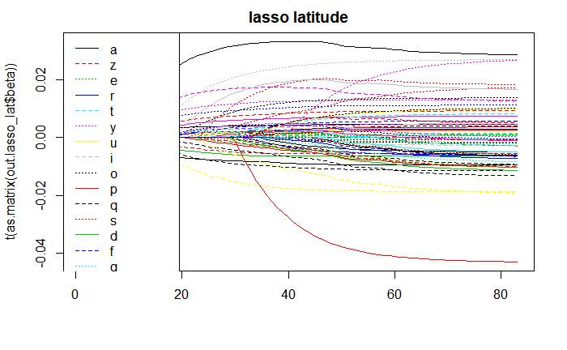

```r
title("lasso latitude")
```

```r
matplot(t(as.matrix(out.lasso_long$beta)),type="l",col=1:10,lty=1:3)
legend("topleft",legend=colnames(logistic_table),col=1:10,lty=1:3)
```

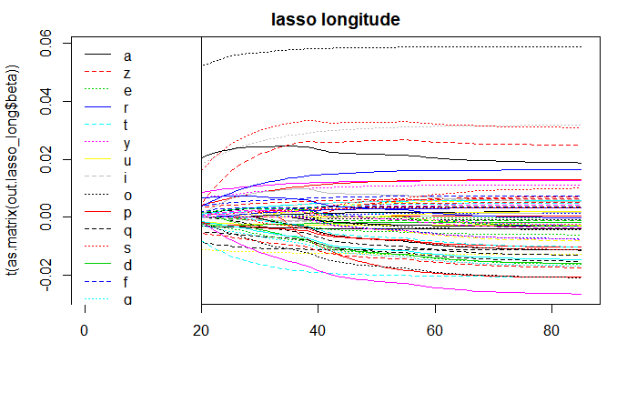

```r
title("lasso longitude")
```

Les paramètres ont correctement convergé.

## Choix de la penalité par validation croisée

```r
latitude.app=as.matrix(COMMUNES$latitude)
a_lat=cv.glmnet(logistic_table,latitude.app)
lambda.opt_lat=a_lat$lambda.min
latitude.lm.lasso=glmnet(logistic_table,latitude.app,lambda=lambda.opt_lat)

longitude.app=as.matrix(COMMUNES$longitude)
a_long=cv.glmnet(logistic_table,longitude.app)
lambda.opt_long=a_long$lambda.min
longitude.lm.lasso=glmnet(logistic_table,longitude.app,lambda=lambda.opt_long)
```

## Calcul de l’erreur quadratique du modèle.

```r
#Erreur sur la base de tests
err_lasso<-matrix(c(mean((test_COMMUNES$latitude-predict.glmnet(latitude.lm.lasso,logistic_table_test,s=lambda.opt_lat))^2),mean((test_COMMUNES$longitude-predict.glmnet(longitude.lm.lasso,logistic_table_test,s=lambda.opt_long))^2)),nrow=1)

#err_lasso

rownames(err_lasso)<-c('Modele Lasso avec lambda opt')
M<-rbind(M,err_lasso)
M
```

```
                                Erreur sur la latitude Erreur sur la longitude
Modele complet                             0.001201088             0.001859551
Modele avec anova type 1                   0.001212520             0.001898814
Modele AIC backward                        0.001201929             0.001860830
Modele BIC backward                        0.001209170             0.001867437
Modele trivial                             0.001441735             0.002063376
Modele singulier                           0.001193490             0.001934674
Modele singulier anova de type1            0.001120777             0.001763056
Modele Lasso avec lambda opt               0.001201422             0.001859416
```

On voit que la relaxation des paramètres est moins importante en fait que l’ajout d’interactions.

Il serait donc intéressant de regarder des syllabes plutôt que les présences/absences de paramètres.

# Regression multivariée : MARS

https://www.rdocumentation.org/packages/polspline/versions/1.1.17/topics/polymars

https://cran.r-project.org/web/packages/polspline/polspline.pdf

Le modèle MARS:

1. N’estime pas indépendamment la latitude et la longitude.
2. Ne repose pas sur une hypothèse de lnéarité des paramètres.

Pour chaque ville i de coordonnées $(longitude_{i},latitude_{i})$:

La fonction de régression sera de la forme:

$f(X):=\sum_{i=1}^{k}c_{i}B_{i}(X_{i})$ avec:

-X la matrice de données définie précédemment.

-les $c_{i}$ constantes

-les $B_{i}$ êtant soit des fonctions constantes/ soit des fonctions de la forme ‘hinge’ $max(X_{i}-cste,0)$ soit un produit de ‘hinge functions’

```r
cities_app<-matrix(nrow=length(COMMUNES$latitude),ncol=2)
cities_app[,2]<-COMMUNES$longitude
cities_app[,1]<-COMMUNES$latitude
Ll.mars<-polymars(responses = cities_app,predictors = logistic_table,factors=TRUE)
```

## Graphe de diagnostique:

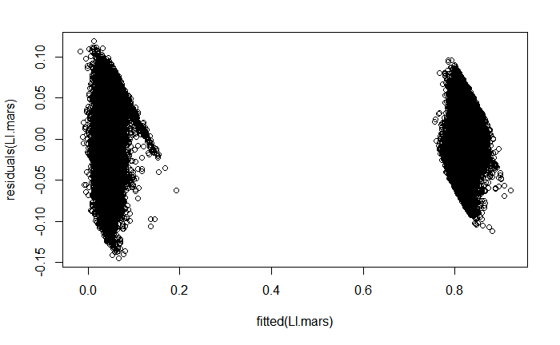

```r
plot(fitted(Ll.mars),residuals(Ll.mars))
```

```r
cities_test_estim<-predict.polymars(object=Ll.mars,x=logistic_table_test )
cities_test<-matrix(nrow=length(test_COMMUNES$latitude),ncol=2)
cities_test[,1]<-test_COMMUNES$latitude
cities_test[,2]<-test_COMMUNES$longitude
err_mars<-matrix(c(mean((cities_test_estim[,1]-cities_test[,1])**2),mean((cities_test_estim[,2]-cities_test[,2])**2)),nrow=1)
rownames(err_mars)<-c('Modele MARS')
M<-rbind(M,err_mars)
M
```

```
                                Erreur sur la latitude Erreur sur la longitude
Modele complet                             0.001201088             0.001859551
Modele avec anova type 1                   0.001212520             0.001898814
Modele AIC backward                        0.001201929             0.001860830
Modele BIC backward                        0.001209170             0.001867437
Modele trivial                             0.001441735             0.002063376
Modele singulier                           0.001193490             0.001934674
Modele singulier anova de type1            0.001120777             0.001763056
Modele Lasso avec lambda opt               0.001201422             0.001859416
Modele MARS                                0.001210827             0.001846130
```

Le modèle linéaire où on a relâché l’hypothèse d’indépendance fait à peu près aussi bien que les modèles linéaires précédents.

# Choix du modele et selection des individus

On choisirait plutôt le modèle singulier avec sélections des variables via anova1

Regardons les villes (de la base de test) les mieux/moins bien placées (au sens de l’erreur quadratique)

```r
#TOP20 latitude
colnames(logistic_table_test)<-p2
latitude.err<-(test_COMMUNES$latitude-predict(latitude.lm2,as.data.frame(logistic_table_test)))**2
top20.lat<-order(latitude.err)[1:20]
test_COMMUNES[top20.lat,]
```

| nom | code_postal | longitude | latitude | departement | region |
| --- | --- | --- | --- | --- | --- |
| Bessoncourt | 90160 | 0.121019191 | 0.8315670 | 90 | FC |
| Mérouville | 28310 | 0.033141864 | 0.8429407 | 28 | CE |
| Sales | 74150 | 0.104041015 | 0.8006649 | 74 | RA |
| Levroux | 36110 | 0.028196771 | 0.8199314 | 36 | CE |
| Cassagnes | 46700 | 0.019916144 | 0.7777090 | 46 | MP |
| Tersannes | 87360 | 0.019586468 | 0.8080583 | 87 | LI |
| Hillion | 22120 | -0.046551806 | 0.8467271 | 22 | BR |
| Grande-Rivière | 39150 | 0.103275007 | 0.8123780 | 39 | FC |
| Bailly-aux-Forges | 52130 | 0.085778080 | 0.8458254 | 52 | CA |
| Tarnès | 33240 | -0.006195919 | 0.7850442 | 33 | AQ |

[output cut: 10 more lines]

```r
#TOP20 longitude
longitude.err<-(test_COMMUNES$longitude-predict(longitude.lm2,as.data.frame(logistic_table_test)))**2
top20.long<-order(longitude.err)[1:20]
test_COMMUNES[top20.long,]
```

| nom | code_postal | longitude | latitude | departement | region |
| --- | --- | --- | --- | --- | --- |
| Busigny | 59137 | 0.06047081 | 0.8732561 | 59 | NP |
| Gournay-sur-Aronde | 60190 | 0.04670695 | 0.8638168 | 60 | PI |
| Cazes-Mondenard | 82110 | 0.02098758 | 0.7719252 | 82 | MP |
| Morienval | 60127 | 0.05096362 | 0.8603891 | 60 | PI |
| Vieuvicq | 28120 | 0.02120090 | 0.8423638 | 28 | CE |
| Nonette | 63340 | 0.05719346 | 0.7937321 | 63 | AU |
| Mareuil-en-Dôle | 2130 | 0.06211918 | 0.8594195 | 2 | PI |
| Millançay | 41200 | 0.03093111 | 0.8280957 | 41 | CE |
| Auradé | 32600 | 0.01846171 | 0.7603866 | 32 | MP |
| Sainte-Solange | 18220 | 0.04448165 | 0.8226658 | 18 | CE |

[output cut: 10 more lines]

```r
#TOP
Ll.err<-sqrt(latitude.err+longitude.err)
top20.Ll<-order(Ll.err)[1:20]
test_COMMUNES[top20.Ll,]
```

| nom | code_postal | longitude | latitude | departement | region |
| --- | --- | --- | --- | --- | --- |
| Gagnac-sur-Cère | 46130 | 0.032783095 | 0.7843413 | 46 | MP |
| Millançay | 41200 | 0.030931110 | 0.8280957 | 41 | CE |
| Chaume-lès-Baigneux | 21450 | 0.080003956 | 0.8312518 | 21 | BO |
| Ervy-le-Châtel | 10130 | 0.068256910 | 0.8384901 | 10 | CA |
| Saint-Amand | 23200 | 0.038503900 | 0.8025460 | 23 | LI |
| Cazes-Mondenard | 82110 | 0.020987584 | 0.7719252 | 82 | MP |
| Lacépède | 47360 | 0.008052757 | 0.7735542 | 47 | AQ |
| Montmort-Lucy | 51270 | 0.066487340 | 0.8538926 | 51 | CA |
| Villery | 10320 | 0.070152532 | 0.8407348 | 10 | CA |
| La_Chapelle-du-Noyer | 28200 | 0.022892907 | 0.8382720 | 28 | CE |

[output cut: 10 more lines]

```r
NA
```

Il est intéressant de noter que les ville les mieux placées aussi bien pour la longitude; la latitude ou les 2 jointement il n’y a pas spécialement de points communs sur les villes les mieux placées. Elles ne sont pas dans la même région ni proches du centre. En revanche elles rappellent les villes ayant l’air d’avoir eu un fort leverage: leurs coordonnées sont sans doutes estimées par elles-mêmes. Ces villes ont ainsi une combinaison de modalités unique.